# R Notebook

## Compare the conditions….

```r
participants_with_promote_prevent <- merge(ppt_list_clean,pmp_fci,by.x = "subid",by.y="subid")
participants_with_promote_prevent$s2_minus_s1 <- participants_with_promote_prevent$`DEV Session 2 Surveys`-participants_with_promote_prevent$`DEV Session 1 Surveys`
```

First do a qualitative look at the three conditions…

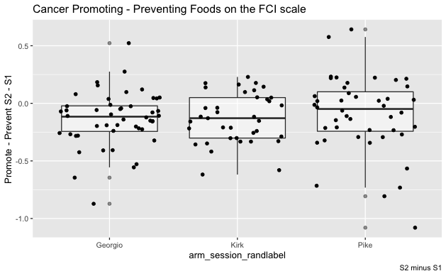

```r
ggplot(participants_with_promote_prevent,aes(x=arm_session_randlabel,y=s2_minus_s1))+geom_boxplot(alpha=0.5)+geom_point(position="jitter")+
  labs(y="Promote - Prevent S2 - S1",title = "Cancer Promoting - Preventing Foods on the FCI scale",caption="S2 minus S1")
```

```r
NA
NA
```

Take the HIGHEST session and make it the baseline

```r
arm_comparison <- participants_with_promote_prevent %>% group_by(arm_session_randlabel) %>% summarise(mean_s2_minus_s1 = mean(s2_minus_s1,na.rm=TRUE))
arm_comparison <- arm_comparison %>% arrange(-mean_s2_minus_s1)


#now do the levelling, in order from lowest to highest.
participants_with_promote_prevent$arm_session_randlabel <- factor(participants_with_promote_prevent$arm_session_randlabel,levels=arm_comparison$arm_session_randlabel)
```

```r
model_session_2_conditions <- lm(`DEV Session 2 Surveys`~`DEV Session 1 Surveys`+arm_session_randlabel, participants_with_promote_prevent)
model_session_2_noconditions <- lm(`DEV Session 2 Surveys`~`DEV Session 1 Surveys`, participants_with_promote_prevent)
summary(model_session_2_conditions)
```

```
Call:
lm(formula = `DEV Session 2 Surveys` ~ `DEV Session 1 Surveys` +
    arm_session_randlabel, data = participants_with_promote_prevent)

Residuals:
     Min       1Q   Median       3Q      Max
-0.89379 -0.12996 -0.00342  0.16608  0.71318

Coefficients:
                             Estimate Std. Error t value Pr(>|t|)
(Intercept)                  -0.04586    0.04123  -1.112    0.268
`DEV Session 1 Surveys`       0.85469    0.03992  21.410   <2e-16 ***
arm_session_randlabelKirk    -0.04190    0.05749  -0.729    0.467
arm_session_randlabelGeorgio -0.05531    0.05387  -1.027    0.307
---
Signif. codes:  0 ‘***’ 0.001 ‘**’ 0.01 ‘*’ 0.05 ‘.’ 0.1 ‘ ’ 1

Residual standard error: 0.2575 on 125 degrees of freedom
  (34 observations deleted due to missingness)
Multiple R-squared:  0.7881,    Adjusted R-squared:  0.783
F-statistic:   155 on 3 and 125 DF,  p-value: < 2.2e-16
```

No difference between the conditions at all.

```r
participants_with_promote_prevent[as.integer(names(model_session_2_noconditions$residuals)),"residuals"] <- model_session_2_noconditions$residuals
```

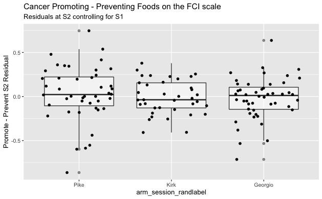

```r
ggplot(participants_with_promote_prevent,aes(x=arm_session_randlabel,y=residuals))+geom_boxplot(alpha=0.5)+geom_point(position="jitter")+
  labs(y="Promote - Prevent S2 Residual",title = "Cancer Promoting - Preventing Foods on the FCI scale",subtitle="Residuals at S2 controlling for S1")
```

## Check assumptions for ANCOVA

### Linearity

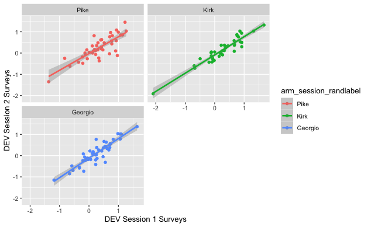

```r
ggplot(participants_with_promote_prevent,aes(`DEV Session 1 Surveys`,`DEV Session 2 Surveys`,group=arm_session_randlabel,color=arm_session_randlabel))+
  geom_point()+geom_smooth(method="lm")+facet_wrap(~arm_session_randlabel,nrow = 2)
```

### Homogeneity of regression slopes

```r
anova_test(participants_with_promote_prevent,`DEV Session 2 Surveys`~arm_session_randlabel*`DEV Session 1 Surveys`)
```

```
NA detected in rows: 4,7,16,22,28,29,30,39,42,46,54,58,66,67,73,79,80,83,87,94,100,105,106,109,132,134,137,145,146,147,152,157,158,162.
Removing this rows before the analysis.Coefficient covariances computed by hccm()
```

```
ANOVA Table (type II tests)

                                         Effect DFn DFd       F        p p<.05   ges
1                         arm_session_randlabel   2 123   0.559 5.73e-01       0.009
2                       `DEV Session 1 Surveys`   1 123 457.201 2.99e-43     * 0.788
3 arm_session_randlabel:`DEV Session 1 Surveys`   2 123   0.840 4.34e-01       0.013
```

Great: no interaction observed.

### Normality of residuals

```r
library(broom)
model.metrics<- augment(model_session_2_conditions) %>% select(-.hat, -.sigma, -.fitted) # Remove details
head(model.metrics, 3)
```

| .rownames | DEV Session 2 Surveys | DEV Session 1 Surveys | arm_session_randlabel | .resid | .cooksd | .std.resid |
| --- | --- | --- | --- | --- | --- | --- |
| 1 | 0.4333333 | 0.57365591 | Georgio | 0.04419819 | 0.0001797484 | 0.1736745 |
| 2 | -0.2333333 | -0.07526882 | Kirk | -0.08124321 | 0.0007990956 | -0.3203776 |
| 3 | 0.3333333 | 0.61397849 | Georgio | -0.09026516 | 0.0007719350 | -0.3548117 |

Test for non-normality of residuals

```r
library(rstatix)
shapiro_test(model.metrics$.resid)
```

| variable | statistic | p.value |
| --- | --- | --- |
| model.metrics$.resid | 0.9724233 | 0.009830801 |

ahhhh. We do have non-normality of residuals. So we may have to get rid of outliers or apply the time corrections. Let’s apply time corrections and only if there is still non-normality of residuals, we’ll remove the outliers.

### homogeniety of variances

```r
#model.metrics %>% levene_test(.resid~arm_session_randlabel)
```

### outliers

```r
model.metrics %>%
  filter(abs(.std.resid) > 3) %>%
  as.data.frame()
```

| .rownames | DEV Session 2 Surveys | DEV Session 1 Surveys | arm_session_randlabel | .resid | .cooksd | .std.resid |
| --- | --- | --- | --- | --- | --- | --- |
| 163 | -0.1166667 | 0.9629032 | Pike | -0.8937932 | 0.1022303 | -3.527558 |

# allow for date started

OK great - we can do this all again for the other inventory we are measuring. then we have to make a decision to pull back the data and inspect which groups are which!

Also–do we want to control for other factors, like Month Began?

standard way to do this in this field might be just try to add a linear trend, then quadratic, then cubic, and so on until it doesn’t improve fit.

```r
library(lubridate)
min_date <- min(participants_with_promote_prevent$date_0)
participants_with_promote_prevent$date_linear <- as.numeric(as.POSIXct(participants_with_promote_prevent$date_0))
# summary(lm(`DEV Session 1 Surveys`~ date_linear, participants_with_promote_prevent))
# summary(lm(`DEV Session 1 Surveys`~ I(date_linear^3), participants_with_promote_prevent))
#no evidence of any date effect here. we could try for a simple seasonality (period of 4 with 2)
participants_with_promote_prevent <-
  participants_with_promote_prevent %>% #select(date_linear,date_0) %>%
  mutate(date_years_linear=as.numeric(difftime(date_0,min(min_date),unit="days"))/365) %>%
  mutate(day_in_year=yday(date_0)) %>%
  mutate(date_years_period1 = sin(date_years_linear*pi)) %>%
  mutate(date_years_period2 = sin(date_years_linear*2*pi)) %>%
  mutate(year_as_factor = as.factor(year(date_0)))



summary(lm(`DEV Session 1 Surveys`~ date_years_linear + date_years_period1 + date_years_period2, participants_with_promote_prevent))
```

```
Call:
lm(formula = `DEV Session 1 Surveys` ~ date_years_linear + date_years_period1 +
    date_years_period2, data = participants_with_promote_prevent)

Residuals:
     Min       1Q   Median       3Q      Max
-2.37513 -0.35516  0.02411  0.40252  1.47825

Coefficients:
                   Estimate Std. Error t value Pr(>|t|)
(Intercept)         0.32407    0.12476   2.597   0.0103 *
date_years_linear  -0.06188    0.10740  -0.576   0.5653
date_years_period1  0.02137    0.08762   0.244   0.8076
date_years_period2 -0.04140    0.07797  -0.531   0.5962
---
Signif. codes:  0 ‘***’ 0.001 ‘**’ 0.01 ‘*’ 0.05 ‘.’ 0.1 ‘ ’ 1

Residual standard error: 0.5821 on 156 degrees of freedom
  (3 observations deleted due to missingness)
Multiple R-squared:  0.007304,  Adjusted R-squared:  -0.01179
F-statistic: 0.3826 on 3 and 156 DF,  p-value: 0.7657
```

```r
#no sign that any of this makes a difference...
```

we should probably control for this.

```r
summary(lm(s2_minus_s1~ date_years_linear + date_years_period1, participants_with_promote_prevent))
```

```
Call:
lm(formula = s2_minus_s1 ~ date_years_linear + date_years_period1,
    data = participants_with_promote_prevent)

Residuals:
    Min      1Q  Median      3Q     Max
-0.9608 -0.1430  0.0122  0.1634  0.7885

Coefficients:
                   Estimate Std. Error t value Pr(>|t|)
(Intercept)        -0.17393    0.06800  -2.558   0.0117 *
date_years_linear   0.05571    0.06663   0.836   0.4047
date_years_period1  0.02067    0.04660   0.444   0.6581
---
Signif. codes:  0 ‘***’ 0.001 ‘**’ 0.01 ‘*’ 0.05 ‘.’ 0.1 ‘ ’ 1

Residual standard error: 0.2696 on 126 degrees of freedom
  (34 observations deleted due to missingness)
Multiple R-squared:  0.005874,  Adjusted R-squared:  -0.009905
F-statistic: 0.3723 on 2 and 126 DF,  p-value: 0.6899
```

```r
summary(lm(s2_minus_s1~ year_as_factor, participants_with_promote_prevent)) #close enough to significance to consider adding it in.
```

```
Call:
lm(formula = s2_minus_s1 ~ year_as_factor, data = participants_with_promote_prevent)

Residuals:
     Min       1Q   Median       3Q      Max
-0.95220 -0.15090  0.00909  0.16953  0.75932

Coefficients:
                    Estimate Std. Error t value Pr(>|t|)
(Intercept)        -0.117381   0.041207  -2.849  0.00513 **
year_as_factor2019 -0.009987   0.051562  -0.194  0.84672
year_as_factor2020  0.023202   0.094865   0.245  0.80718
---
Signif. codes:  0 ‘***’ 0.001 ‘**’ 0.01 ‘*’ 0.05 ‘.’ 0.1 ‘ ’ 1

Residual standard error: 0.2702 on 126 degrees of freedom
  (34 observations deleted due to missingness)
Multiple R-squared:  0.001174,  Adjusted R-squared:  -0.01468
F-statistic: 0.07403 on 2 and 126 DF,  p-value: 0.9287
```

```r
summary(lm(s2_minus_s1~ day_in_year*year_as_factor + date_years_period1*year_as_factor, participants_with_promote_prevent))
```

```
Call:
lm(formula = s2_minus_s1 ~ day_in_year * year_as_factor + date_years_period1 *
    year_as_factor, data = participants_with_promote_prevent)

Residuals:
     Min       1Q   Median       3Q      Max
-0.89557 -0.14464  0.01296  0.15902  0.75289

Coefficients:
                                       Estimate Std. Error t value Pr(>|t|)
(Intercept)                           -0.160113   0.234255  -0.683    0.496
day_in_year                           -0.001814   0.002183  -0.831    0.408
year_as_factor2019                     0.020382   0.370007   0.055    0.956
year_as_factor2020                     1.535432   1.266519   1.212    0.228
date_years_period1                     0.626490   0.457551   1.369    0.173
day_in_year:year_as_factor2019         0.001825   0.003153   0.579    0.564
day_in_year:year_as_factor2020        -0.007792   0.008472  -0.920    0.360
year_as_factor2019:date_years_period1 -0.678325   0.562263  -1.206    0.230
year_as_factor2020:date_years_period1  1.071361   1.495368   0.716    0.475

Residual standard error: 0.2697 on 120 degrees of freedom
  (34 observations deleted due to missingness)
Multiple R-squared:  0.05219,   Adjusted R-squared:  -0.01099
F-statistic: 0.826 on 8 and 120 DF,  p-value: 0.5813
```

No sign that these factors matter…

```r
model_session_2_m2 <- lm(`DEV Session 2 Surveys`~`DEV Session 1 Surveys`+arm_session_randlabel + day_in_year*year_as_factor + date_years_period1*year_as_factor, participants_with_promote_prevent)
summary(model_session_2_m2)
```

```
Call:
lm(formula = `DEV Session 2 Surveys` ~ `DEV Session 1 Surveys` +
    arm_session_randlabel + day_in_year * year_as_factor + date_years_period1 *
    year_as_factor, data = participants_with_promote_prevent)

Residuals:
     Min       1Q   Median       3Q      Max
-0.85022 -0.12304  0.00488  0.15657  0.72933

Coefficients:
                                       Estimate Std. Error t value Pr(>|t|)
(Intercept)                           -0.182845   0.226662  -0.807    0.421
`DEV Session 1 Surveys`                0.851491   0.040825  20.857   <2e-16 ***
arm_session_randlabelKirk             -0.058316   0.059023  -0.988    0.325
arm_session_randlabelGeorgio          -0.036338   0.056398  -0.644    0.521
day_in_year                           -0.001067   0.002107  -0.507    0.613
year_as_factor2019                     0.106339   0.355148   0.299    0.765
year_as_factor2020                     1.859951   1.232126   1.510    0.134
date_years_period1                     0.504476   0.443119   1.138    0.257
day_in_year:year_as_factor2019         0.001211   0.003034   0.399    0.691
day_in_year:year_as_factor2020        -0.009750   0.008216  -1.187    0.238
year_as_factor2019:date_years_period1 -0.516331   0.542589  -0.952    0.343
year_as_factor2020:date_years_period1  1.438625   1.446591   0.994    0.322
---
Signif. codes:  0 ‘***’ 0.001 ‘**’ 0.01 ‘*’ 0.05 ‘.’ 0.1 ‘ ’ 1

Residual standard error: 0.2583 on 117 degrees of freedom
  (34 observations deleted due to missingness)
Multiple R-squared:  0.8004,    Adjusted R-squared:  0.7816
F-statistic: 42.65 on 11 and 117 DF,  p-value: < 2.2e-16
```

I think we need to remove that outlier, and then try modeling again.

```r
model.metrics %>%
  filter(abs(.std.resid) > 3) %>% print
```

| .rownames | DEV Session 2 Surveys | DEV Session 1 Surveys | arm_session_randlabel | .resid | .cooksd | .std.resid |
| --- | --- | --- | --- | --- | --- | --- |
| 163 | -0.1166667 | 0.9629032 | Pike | -0.8937932 | 0.1022303 | -3.527558 |

```r
ppp_fci_no_outliers <- participants_with_promote_prevent[-52, ]
```

First do a qualitative look at the three conditions…

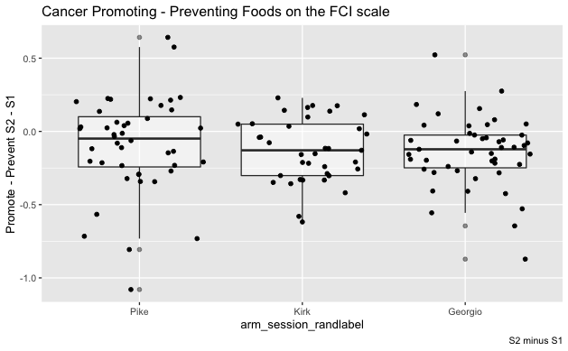

```r
ggplot(ppp_fci_no_outliers,aes(x=arm_session_randlabel,y=s2_minus_s1))+geom_boxplot(alpha=0.5)+geom_point(position="jitter")+
  labs(y="Promote - Prevent S2 - S1",title = "Cancer Promoting - Preventing Foods on the FCI scale",caption="S2 minus S1")
```

```r
NA
NA
```

Take the lowest session and make it the baseline

```r
arm_comparison <- ppp_fci_no_outliers %>% group_by(arm_session_randlabel) %>% summarise(mean_s2_minus_s1 = mean(s2_minus_s1,na.rm=TRUE))
arm_comparison <- arm_comparison %>% arrange(mean_s2_minus_s1)


#now do the levelling, in order from lowest to highest.
ppp_fci_no_outliers$arm_session_randlabel <- factor(ppp_fci_no_outliers$arm_session_randlabel,levels=arm_comparison$arm_session_randlabel)
```

```r
model_session_2_conditions <- lm(`DEV Session 2 Surveys`~`DEV Session 1 Surveys`+arm_session_randlabel, ppp_fci_no_outliers)
model_session_2_noconditions <- lm(`DEV Session 2 Surveys`~`DEV Session 1 Surveys`, ppp_fci_no_outliers)
summary(model_session_2_conditions)
```

```
Call:
lm(formula = `DEV Session 2 Surveys` ~ `DEV Session 1 Surveys` +
    arm_session_randlabel, data = ppp_fci_no_outliers)

Residuals:
     Min       1Q   Median       3Q      Max
-0.89526 -0.12767 -0.00824  0.16784  0.71360

Coefficients:
                          Estimate Std. Error t value Pr(>|t|)
(Intercept)               -0.10425    0.03925  -2.656  0.00895 **
`DEV Session 1 Surveys`    0.85708    0.04040  21.217  < 2e-16 ***
arm_session_randlabelKirk  0.01580    0.05678   0.278  0.78121
arm_session_randlabelPike  0.05756    0.05428   1.061  0.29096
---
Signif. codes:  0 ‘***’ 0.001 ‘**’ 0.01 ‘*’ 0.05 ‘.’ 0.1 ‘ ’ 1

Residual standard error: 0.2583 on 124 degrees of freedom
  (34 observations deleted due to missingness)
Multiple R-squared:  0.7861,    Adjusted R-squared:  0.7809
F-statistic: 151.9 on 3 and 124 DF,  p-value: < 2.2e-16
```

No difference between the conditions at all.

```r
ppp_fci_no_outliers[as.integer(names(model_session_2_noconditions$residuals)),"residuals"] <- model_session_2_noconditions$residuals
```

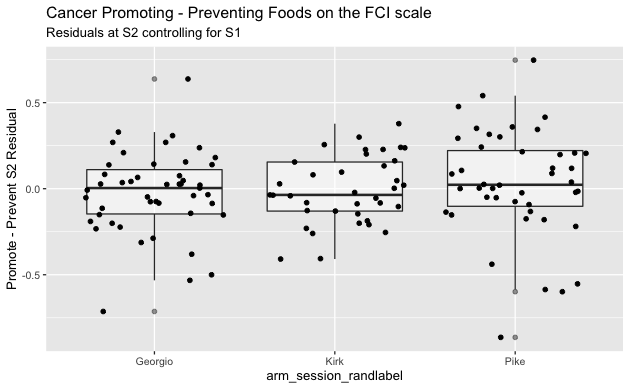

```r
ggplot(ppp_fci_no_outliers,aes(x=arm_session_randlabel,y=residuals))+geom_boxplot(alpha=0.5)+geom_point(position="jitter")+
  labs(y="Promote - Prevent S2 Residual",title = "Cancer Promoting - Preventing Foods on the FCI scale",subtitle="Residuals at S2 controlling for S1")
```

## Check assumptions for ANCOVA

### Linearity

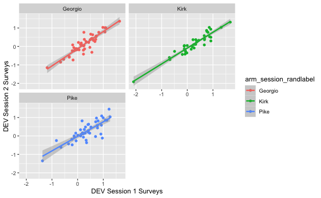

```r
ggplot(ppp_fci_no_outliers,aes(`DEV Session 1 Surveys`,`DEV Session 2 Surveys`,group=arm_session_randlabel,color=arm_session_randlabel))+
  geom_point()+geom_smooth(method="lm")+facet_wrap(~arm_session_randlabel,nrow = 2)
```

### Homogeneity of regression slopes

```r
anova_test(ppp_fci_no_outliers,`DEV Session 2 Surveys`~arm_session_randlabel*`DEV Session 1 Surveys`)
```

```
NA detected in rows: 4,7,16,22,28,29,30,39,42,46,53,57,65,66,72,78,79,82,86,93,99,104,105,108,131,133,136,144,145,146,151,156,157,161.
Removing this rows before the analysis.Coefficient covariances computed by hccm()
```

```
ANOVA Table (type II tests)

                                         Effect DFn DFd       F        p p<.05   ges
1                         arm_session_randlabel   2 122   0.590 5.56e-01       0.010
2                       `DEV Session 1 Surveys`   1 122 449.898 9.56e-43     * 0.787
3 arm_session_randlabel:`DEV Session 1 Surveys`   2 122   0.964 3.84e-01       0.016
```

Great: no interaction observed.

### Normality of residuals

```r
library(broom)
model.metrics<- augment(model_session_2_conditions) %>% select(-.hat, -.sigma, -.fitted) # Remove details
head(model.metrics, 3)
```

| .rownames | DEV Session 2 Surveys | DEV Session 1 Surveys | arm_session_randlabel | .resid | .cooksd | .std.resid |
| --- | --- | --- | --- | --- | --- | --- |
| 1 | 0.4333333 | 0.57365591 | Georgio | 0.04591505 | 0.0001946249 | 0.1798656 |
| 2 | -0.2333333 | -0.07526882 | Kirk | -0.08037444 | 0.0007786317 | -0.3159504 |
| 3 | 0.3333333 | 0.61397849 | Georgio | -0.08864470 | 0.0007459733 | -0.3473656 |

Test for non-normality of residuals

```r
library(rstatix)
shapiro_test(model.metrics$.resid)
```

| variable | statistic | p.value |
| --- | --- | --- |
| model.metrics$.resid | 0.9723219 | 0.01003135 |

### homogeniety of variances

```r
#model.metrics %>% levene_test(.resid~arm_session_randlabel)
```

### outliers

```r
model.metrics %>%
  filter(abs(.std.resid) > 3) %>%
  as.data.frame()
```

| .rownames | DEV Session 2 Surveys | DEV Session 1 Surveys | arm_session_randlabel | .resid | .cooksd | .std.resid |
| --- | --- | --- | --- | --- | --- | --- |
| 162 | -0.1166667 | 0.9629032 | Pike | -0.8952634 | 0.1024553 | -3.522386 |

# allow for date started

OK great - we can do this all again for the other inventory we are measuring. then we have to make a decision to pull back the data and inspect which groups are which!

Also–do we want to control for other factors, like Month Began?

standard way to do this in this field might be just try to add a linear trend, then quadratic, then cubic, and so on until it doesn’t improve fit.

```r
library(lubridate)
min_date <- min(ppp_fci_no_outliers$date_0)
ppp_fci_no_outliers$date_linear <- as.numeric(as.POSIXct(ppp_fci_no_outliers$date_0))
# summary(lm(`DEV Session 1 Surveys`~ date_linear, participants_with_promote_prevent))
# summary(lm(`DEV Session 1 Surveys`~ I(date_linear^3), participants_with_promote_prevent))
#no evidence of any date effect here. we could try for a simple seasonality (period of 4 with 2)
ppp_fci_no_outliers <-
  ppp_fci_no_outliers %>% #select(date_linear,date_0) %>%
  mutate(date_years_linear=as.numeric(difftime(date_0,min(min_date),unit="days"))/365) %>%
  mutate(day_in_year=yday(date_0)) %>%
  mutate(date_years_period1 = sin(date_years_linear*pi)) %>%
  mutate(date_years_period2 = sin(date_years_linear*2*pi)) %>%
  mutate(year_as_factor = as.factor(year(date_0)))



summary(lm(`DEV Session 1 Surveys`~ date_years_linear + date_years_period1 + date_years_period2, ppp_fci_no_outliers))
```

```
Call:
lm(formula = `DEV Session 1 Surveys` ~ date_years_linear + date_years_period1 +
    date_years_period2, data = ppp_fci_no_outliers)

Residuals:
     Min       1Q   Median       3Q      Max
-2.39489 -0.33826  0.01155  0.39246  1.48167

Coefficients:
                   Estimate Std. Error t value Pr(>|t|)
(Intercept)         0.32619    0.12424   2.626  0.00952 **
date_years_linear  -0.06017    0.10695  -0.563  0.57453
date_years_period1  0.03350    0.08760   0.382  0.70265
date_years_period2 -0.03368    0.07780  -0.433  0.66571
---
Signif. codes:  0 ‘***’ 0.001 ‘**’ 0.01 ‘*’ 0.05 ‘.’ 0.1 ‘ ’ 1

Residual standard error: 0.5796 on 155 degrees of freedom
  (3 observations deleted due to missingness)
Multiple R-squared:  0.008788,  Adjusted R-squared:  -0.0104
F-statistic: 0.4581 on 3 and 155 DF,  p-value: 0.712
```

```r
#no sign that any of this makes a difference...
```

we should probably control for this.

```r
summary(lm(s2_minus_s1~ date_years_linear + date_years_period1, ppp_fci_no_outliers))
```

```
Call:
lm(formula = s2_minus_s1 ~ date_years_linear + date_years_period1,
    data = ppp_fci_no_outliers)

Residuals:
     Min       1Q   Median       3Q      Max
-0.95696 -0.14315  0.01323  0.16243  0.79241

Coefficients:
                   Estimate Std. Error t value Pr(>|t|)
(Intercept)        -0.17640    0.06814  -2.589   0.0108 *
date_years_linear   0.05672    0.06671   0.850   0.3969
date_years_period1  0.01822    0.04673   0.390   0.6974
---
Signif. codes:  0 ‘***’ 0.001 ‘**’ 0.01 ‘*’ 0.05 ‘.’ 0.1 ‘ ’ 1

Residual standard error: 0.2699 on 125 degrees of freedom
  (34 observations deleted due to missingness)
Multiple R-squared:  0.00646,   Adjusted R-squared:  -0.009437
F-statistic: 0.4064 on 2 and 125 DF,  p-value: 0.6669
```

```r
summary(lm(s2_minus_s1~ year_as_factor, ppp_fci_no_outliers)) #close enough to significance to consider adding it in.
```

```
Call:
lm(formula = s2_minus_s1 ~ year_as_factor, data = ppp_fci_no_outliers)

Residuals:
     Min       1Q   Median       3Q      Max
-0.95220 -0.14819  0.01123  0.16742  0.76444

Coefficients:
                    Estimate Std. Error t value Pr(>|t|)
(Intercept)        -0.122505   0.041753  -2.934  0.00398 **
year_as_factor2019 -0.004863   0.052026  -0.093  0.92568
year_as_factor2020  0.028326   0.095211   0.298  0.76657
---
Signif. codes:  0 ‘***’ 0.001 ‘**’ 0.01 ‘*’ 0.05 ‘.’ 0.1 ‘ ’ 1

Residual standard error: 0.2706 on 125 degrees of freedom
  (34 observations deleted due to missingness)
Multiple R-squared:  0.001066,  Adjusted R-squared:  -0.01492
F-statistic: 0.06667 on 2 and 125 DF,  p-value: 0.9355
```

```r
summary(lm(s2_minus_s1~ day_in_year*year_as_factor + date_years_period1*year_as_factor, ppp_fci_no_outliers))
```

```
Call:
lm(formula = s2_minus_s1 ~ day_in_year * year_as_factor + date_years_period1 *
    year_as_factor, data = ppp_fci_no_outliers)

Residuals:
    Min      1Q  Median      3Q     Max
-0.8956 -0.1419  0.0148  0.1610  0.7575

Coefficients:
                                       Estimate Std. Error t value Pr(>|t|)
(Intercept)                           -0.166557   0.235218  -0.708    0.480
day_in_year                           -0.001708   0.002198  -0.777    0.439
year_as_factor2019                     0.026826   0.371259   0.072    0.943
year_as_factor2020                     1.541876   1.270236   1.214    0.227
date_years_period1                     0.596629   0.462012   1.291    0.199
day_in_year:year_as_factor2019         0.001718   0.003168   0.542    0.589
day_in_year:year_as_factor2020        -0.007898   0.008499  -0.929    0.355
year_as_factor2019:date_years_period1 -0.648464   0.566446  -1.145    0.255
year_as_factor2020:date_years_period1  1.101222   1.500657   0.734    0.464

Residual standard error: 0.2705 on 119 degrees of freedom
  (34 observations deleted due to missingness)
Multiple R-squared:  0.04964,   Adjusted R-squared:  -0.01425
F-statistic: 0.777 on 8 and 119 DF,  p-value: 0.6237
```

No sign that these factors matter…

```r
model_session_2_m2 <- lm(`DEV Session 2 Surveys`~`DEV Session 1 Surveys`+arm_session_randlabel + day_in_year*year_as_factor + date_years_period1*year_as_factor, ppp_fci_no_outliers)
summary(model_session_2_m2)
```

```
Call:
lm(formula = `DEV Session 2 Surveys` ~ `DEV Session 1 Surveys` +
    arm_session_randlabel + day_in_year * year_as_factor + date_years_period1 *
    year_as_factor, data = ppp_fci_no_outliers)

Residuals:
     Min       1Q   Median       3Q      Max
-0.85100 -0.12404  0.00475  0.15972  0.73010

Coefficients:
                                       Estimate Std. Error t value Pr(>|t|)
(Intercept)                           -0.221002   0.227576  -0.971    0.334
`DEV Session 1 Surveys`                0.852202   0.041303  20.633   <2e-16 ***
arm_session_randlabelKirk             -0.020910   0.059311  -0.353    0.725
arm_session_randlabelPike              0.037355   0.057089   0.654    0.514
day_in_year                           -0.001041   0.002124  -0.490    0.625
year_as_factor2019                     0.107626   0.356761   0.302    0.763
year_as_factor2020                     1.857002   1.237494   1.501    0.136
date_years_period1                     0.496335   0.448685   1.106    0.271
day_in_year:year_as_factor2019         0.001181   0.003054   0.387    0.700
day_in_year:year_as_factor2020        -0.009750   0.008250  -1.182    0.240
year_as_factor2019:date_years_period1 -0.508641   0.547575  -0.929    0.355
year_as_factor2020:date_years_period1  1.442017   1.452885   0.993    0.323
---
Signif. codes:  0 ‘***’ 0.001 ‘**’ 0.01 ‘*’ 0.05 ‘.’ 0.1 ‘ ’ 1

Residual standard error: 0.2594 on 116 degrees of freedom
  (34 observations deleted due to missingness)
Multiple R-squared:  0.7982,    Adjusted R-squared:  0.7791
F-statistic: 41.71 on 11 and 116 DF,  p-value: < 2.2e-16
```

OK. Lame. We can’t claim any effect from the FCI data! But there was a reasonable group effect in the FFQ dataset. We need to know…what it was, though, so need to perform the same analysis without the masking imposed.

## Session 3 Follow-up after in-depth FFQ analysis.

```r
 promote_minus_prevent$scale_name
```

[output not shown]